# Introdução

Renato Naville Watanabe

O estudo da Engenharia se ocupa em boa parte do estudo de Sistemas. Se você está fazendo esse curso, você já deve ter feito diversos outros cursos sobre diferentes tipos de sistemas, como sistemas mecânicos, elétricos, biológicos, térmicos, fluídicos, econômicos, sociais, entre muitos outros.

**Sistemas nada mais são do que conjuntos de componentes que se interligam para realizar alguma coisa**.

## Exemplos

Vamos ver alguns exemplos de sistemas.

### Circuito RC

[figure not shown]

### Eletrocardiograma

Outro exemplo é o eletrocardiograma, em que o potencial elétrico dos músculos cardíacos são captados por eletrodos e mostrados na tela ou papel em forma gráfica.

[figure not shown]

Nós podemos colocar o aparelho de ECG como um diagrama de blocos:

[figure not shown]

### Corpo humano

Outro exemplo é o corpo humano, que é um sistema composto de diversos outros sistemas.

[figure not shown]

Cada subsistema do corpo humano realiza alguma ação em resposta a algum estímulo.

Abaixo está o diagrama de blocos de um subsistema específico do corpo humano, o pâncreas:

[figure not shown]

O pâncreas libera insulina de acordo com o nível de glicose no sangue.

### Movimento do motorista dentro de um carro

Um outro exemplo é o movimento que a cabeça do motorista faz quando o carro balança. Essa análise em um estudo de ergonomia do carro pode ser importante.

[figure not shown]

O diagrama de blocos desse sistema é:

[figure not shown]

### Forno

Um outro exemplo seria a temperatura dentro do forno após o fogo ser ligado.

[figure not shown]

O diagrama de blocos do forno é:

[figure not shown]

### Inflação

Um outro possível sistema seria considerar o sistema econômico do Brasil e medir a sua taxa de inflação a cada mês em resposta, por exemplo, à taxa de juros.

[figure not shown]

## O formalismo da teoria de sistemas

Toda a teoria de sistemas é baseada no formalismo abaixo:

[figure not shown]

Como pôde ser visto nos exemplos acima, esse formalismo serve para muitos tipos de sistemas. Ele será usado até o final do curso.

Sistemas podem ter um ou mais sinais de entrada de saída. Neste curso consideraremos apenas sistemas com uma entrada e uma saída.

## Sinais

**Sinais são funções, na maioria das vezes do tempo, que vão servir de entrada e de saída para os sistemas.**

Sinais podem representar diversos fenômenos, como velocidade de um carro, voz de uma pessoa, força exercida por um músculo, batimentos cardíacos, taxa de juros ao longo dos meses, entre infinitos outros exemplos.

Matematicamente, sinais são representados como sendo gerados por funções de uma ou mais variáveis independentes. Aqui, consideraremos apenas uma **variável independente**, e na maioria das vezes, é o **tempo**.

### Sinais de tempo contínuo

Para deixar claro que um sinal é de tempo contínuo, o tempo será sempre denotado por $t$ e estará entre parânteses. Por exempo,

$$x(t) = \cos(2\pi t) $$

Os sinais de tempo contínuo têm valores para todo $t$ pertencente ao conjunto dos números reais.

Podemos representar um sinal contínuo através da forma gráfica.

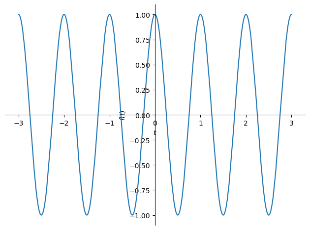

```
<sympy.plotting.plot.Plot at 0x7fc9f152b700>
```

```python
import sympy as sym

t = sym.symbols('t')
sym.plot(sym.cos(2*sym.pi*t), (t,-3,3))
```

### Sinais de tempo discreto

Para deixar claro que um sinal é de tempo discreto, o tempo será representado por $n$ entre colchetes. Por exemplo:

$$x[n] = \cos\left(\frac{2\pi n}{N}\right) $$

Os sinais de tempo discreto só têm valores para $n$ inteiro. Eles não são definidos para $n$ entre os inteiros.

Podemos representar um sinal de tempo discreto na forma gráfica. É comum usar o tipo de gráfico conhecido como *stem* para representar sinais de tempo discreto. Esse tipo de gráfico consiste em usar barras que vão do zero até o valor do sinal com uma pequena bolinha na sua ponta. É esse tipo de gráfico que usaremos no curso para sinais de tempo discreto. O gráfico do sinal acima é:

```
<StemContainer object of 3 artists>
```

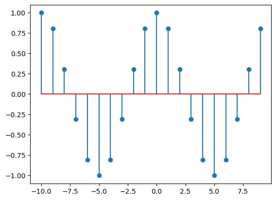

```python
import numpy as np
import matplotlib.pyplot as plt

N = 10
n = np.arange(-10,10)
plt.stem(n, np.cos(2*np.pi*n/N))
```

## Relação entre os sinais de tempo contínuo e discreto

```
<StemContainer object of 3 artists>
```

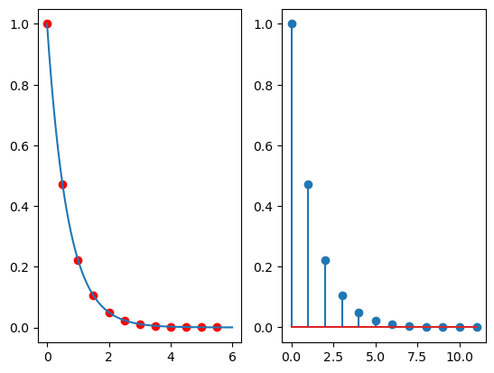

```python
plt.subplot(1,2,1)
tau = 1.5
t = np.arange(0, 6, 0.01)
x = np.exp(-tau*t)
plt.plot(t, x)
T = 0.5
tamos = np.arange(0, 6, T)
xamos = np.exp(-tau*tamos)
plt.scatter(tamos, xamos, color='red')
plt.subplot(1,2,2)
n = np.arange(12)
xdis = np.exp(-tau*n*T)
plt.stem(n, xdis)
```

Mais adiante, veremos mais as implicações de se fazer a amostragem de um sinal.

## Importância dentro da Engenharia

O conteúdo visto neste curso tem importância em várias áreas da Engenharia:

- Processamento de Sinais
- Instrumentação
- Controle
- Modelagem
- Aprendizado de máquinas

## Referências

- Oppenheim, M. e Willsky, S., Sistemas e Sinais, 2010
- Ulaby, FT e Yagle, AE, Signals & Systems: Theory and Applications, 2018, ss2.eecs.umich.edu